# ANÁLISIS Y PREDICCIÓN DE LAS CAUSAS DE INCENDIOS FORESTALES EN GALICIA

15/09/2021

# PREPROCESADO

1. IMPORTACIÓN DE LIBRERÍAS
2. CREACIÓN DE DIRECTORIO DE TRABAJO E IMPORTACIÓN DE LOS DATOS
3. DESCRIPCIÓN GENERAL DEL DATASET : INSPECCIÓN ANALÍTICA Y VISUAL
4. TRANSFORMACIÓN Y CREACIÓN DE VARIABLES
5. ESTUDIO Y TRATAMIENTO DE OUTLIERS
6. ESTUDIO Y TRATAMIENTO DE VALORES PERDIDOS

### 1. IMPORTACIÓN DE LIBRERÍAS

Vamos a importar las librerías que utilizaremos para la limpieza y el tratamiento de los datos.

### 2. CREACIÓN DE DIRECTORIO DE TRABAJO E IMPORTACIÓN DE LOS DATOS

Tenemos dos alternativas para la lectura de los datos: fijando un directorio de trabajo o leyendo los dataset desde una ubicación web

Porfavor, fije su directorio de trabajo en la carpeta del GRUPO 3

Lectura de datos desde github

### 3. DESCRIPCIÓN GENERAL DEL DATASET : INSPECCIÓN ANALÍTICA Y VISUAL

En este script contamos con 2 datasets.El de “datos” reúne la información del conjunto del territorio español y el de “datos_galicia” en el que se va a fundamentar este proyecto. Este dataset es una combinación de dos anteriores, la parte relativa a Galicia del de datos y un conjunto de variables geográficas y geológicas añadidas a posteriori.

Tenemos un total de 33 variables, de las cuales 14 están en el formato de character, 16 en formato de entero y 3 en formato numérico.

En un primer vistazo vemos que el tipo de formato de estas variables lo tendríamos que transformar, para poder trabajar mejor con ellas.

En este sentido vamos a transformar la variable de fecha en el formato date y las variables geográficas y geológicas en numéricas:

También hemos considerado eliminar las variables de id concatenado, latlng_explicit y causa_supuesta, porque por la descripción de su contenido la relevancia en nuestro análisis va a ser muy reducida.

Revisamos de nuevo las numéricas para ver si alguna más podría ser transformada en factor,y realizaremos esta transformación en el apartado siguiente

En la transformación de variables que se realizarán a continuación , cambiará el contenido de la variable y el tipo de datos. En algunos casos la la intención es mejorar la interpretabilidad del modelo y en otros, evitar la pérdida de observaciones en el tratamiento de valores extremos y de valores perdidos.

```
## [1] 25
```

```
## [1] 2
```

### 4. TRANSFORMACIÓN Y CREACIÓN DE NUEVAS VARIABLES

Vamos a hacer una revisión rápida del contenido de cada una de las variables :

Por lo observado, podría ser significativo realizar las siguientes tranformaciones:

**- Transformación de idprovincia, municipio y comunidad**

Esta variable se va a categorizar porque así va a ser más informativa de esta forma y por su contenido no tiene sentido tratarla como si fuera numérica.De igual manera se procederá con la variable del municipio.

**- Transformación de causas a categórica**

En la variable objetivo categórica se van a simplificar dos tipologías de causa en una sola ya que la información que reúnen es la misma.

**- Creación de nuevas columnas en fecha para : trimestre, años y meses**

Se van a crear 3 varias temporales a partir de “fecha” para mejorar la intrepretabilidad.

**- Tranformación de las variables de tiempo**

Se cambiará el formato de las dos variables temporales de minutos a horas sobretodo por cuestiones de interpretabilidad, ya que es más sencillo de valorar en el momento la gravedad del incendio si la duración y el tiempo de extinción se presentan en horas y minutos que en el total de minutos.

**- Dicotomizar muertos heridos**

Se van a dicotimizar estas variables asumiendo que en las observaciones donde se dispone de información recogida el valor va a ser 1.

**- Categorizar la dirección del viento en función de 8 ejes**

Esta variable se va a tramificar asignándole una orientación en función de los grados que tenga. Hay 8 categorías posibles.

**- Dicotomizar precipitaciones**

Esta variable tiene un número de observaciones cuyo valor es cero, muy elevado. Puede ser más significativo el hecho en sí de que las haya o de que no las haya, por eso se va a dicotimizar.

**- Sustituir presión máxima y mínima por una columna con su rango**

Se ha creado una nueva variable que sintetiza la información de dos variables de presión máxima y presión mínima en una sola , que es el rango.

**- Categorizar los gastos**

A raíz del la función summary inicial, se ha visto que la variable de gastos tenía una proporción importante de valores perdidos y parecía razonable categorizarla.

### 5. ESTUDIO Y TRATAMIENTO DE OUTLIERS - VALORES EXTREMOS

#### 5.1 Identificación de los outliers

- Se han creado varias funciones para este propósito ( ver código).

Se va a crear un subset de variables numéricas para representar un primer boxplot con las transformaciones que tenemos.Para ello, la columna de id se fija como nombre de las filas y la variable objetivo de la causa se elimina.De este dataset se extraen las numéricas que se representarán.

Dentro de input se hace un subset para las numéricas y otro para las categóricas porque la identificación es distinta:

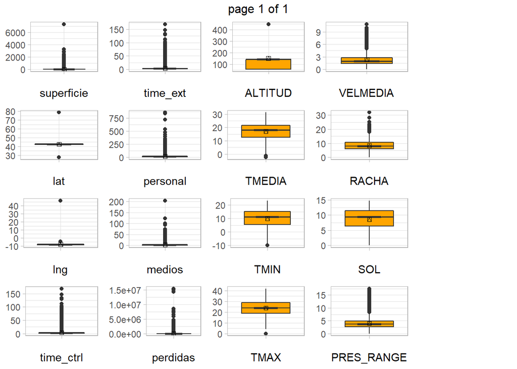

En la mayoría de variables es evidente que hay valores extremos y a raíz del análisis gráfico, recibirán tratamientos distintos:

Para cada una de las variables contenidas en el subset de numéricas input, se van a identificar los valores extremos así como calcular su incidencia. Después se crea el dataframe de incidencia a partir de este, que contendrá en una columna los nombres de las variables y en otra su incidencia.

En este dataset se realizará un tramiento parcial de los valores atípicos ya que algunos casos pueden llegar a ser considerados puntos de interés . Por ejemplo, en el caso de la superficie quemada,la presencia de valores anómalos es fuerte en esta variable, ya que un porcentaje significativo de las observaciones se corresponde con extensiones muy elevadas de terrenos quemado. La presencia de incendios con estas grandes dimensiones, aunque sea reducida en su conjunto es significativa, por eso no podemos omitirla en su totalidad.

#### 5.2 Tratamiento de los outliers

En primer lugar se ha visto que en la variable de altitud el porcentaje de extremos es muy alto por lo que se va a categorizar para evitar tener que eliminar un 12,27 % de las observaciones. En este caso la transformación a variables categóricas va a ser una tramificación

**- Tramificar altitud**

Después de realizar esta transformación hay que que volver a cargar la parte correspondiente de las variables numéricas para conocer la incidencia de las variables restantes como numéricas.

Se comienza con la eliminación de los valores extremos de las variables de medios, superficie, el tiempo transcurrido hasta entrar en fase de control del incendio ( time_ctrl) y el tiempo transcurrido hasta la extinción del incendio ( time_ext)

Una vez eliminados estos outliers, se realizará otra transformación de la variable de VELMEDIA, ya que el porcentaje de valores extremos (9.16%) sobre el total de las observaciones es significativo, por lo que se va a categorizar.

**- Categorizar velocidad media**

Se representa el boxplot para ver cómo ha quedado finalmente la distribución de los valores extremos:

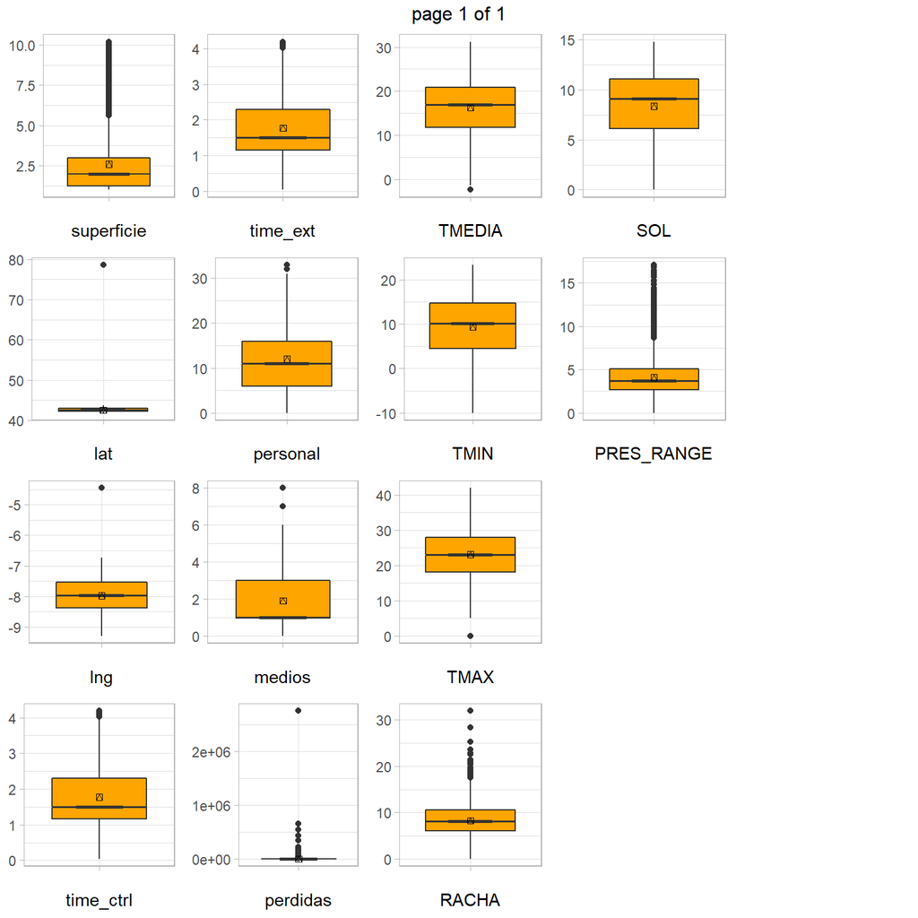

No se van a tratar los outliers en la variable de pérdidas porque a partir de la funcións de summary inicial se ha visto el elevado número elevado de observaciones perdidas y muy posiblemente sea eliminada esta variable.

### 6. ESTUDIO Y TRATAMIENTO DE VALORES PERDIDOS

En esta asegura que la eliminación de los valores sea efectiva, ya que no proporcionan información e impiden la correcta aplicación de los modelos al dataset.

Ahora se identificarán los valores faltantes:

#### 6.1 Localización

Vamos a comprobar la cantidad de valores perdidos por cada una de las variables en valor absoluto y porcentual

Las posibilidades del tratamiento son las mismas que para los outliers: la eliminación de las filas o la imputación de estos valores por la media o la mediana.

- En el caso de la variable de pérdidas se eliminarán en vez de imputar ya que el rango es demasiado grande para imputar.

*En el caso de las variables categóricas de dirección del viento y de velocidad media, de igual manera es muy arriesgado situar todas las observaciones perdidas en una de las categorías, porque distorsionaría el dataset.

Se van a eliminar las observaciones en estas 3 variables que están afectadas y comprobaremos de nuevo la presencia de valores perdidos.

Se elimina la variable de pérdidas por el alto % de NAs.